# Stawberries: exploratory data analysis

Author

MA615 TSZWAI NG

Published

October 11, 2023

The data set for this assignment has been selected from: [USDA_NASS](https://quickstats.nass.usda.gov)  
The data have been stored on NASS here: [USDA_NASS_strawb_2023SEP19](https://quickstats.nass.usda.gov/results/45FBC825-B104-38E2-9802-839F5F3C7036)

Make relevant observations in the document and in your code about data. Add commentary to the code so that anthoer analysts could use or extend your code.

Discusss missing data, inclding how you handled it. Be careful to point out where NA’s are being produced during processing and are not data missing in the original data.

Where it is relevant, include information of how you have organized the data for analysis. It might, for example, be helpful to know that there is both agricultural census data and survey data. It might be helpful to discuss data that appears to be redundant between these two sources.

Make sure you include details in your discussion and in your code about other data and information you used in your work. Cite sources and provide detail that would allow another analyst to reproduce your work.

## EDA

Once the data has been cleaned and organized, you must conduct your own EDA. Be sure to include a discussion of your analysis of the chemical information, including citations for data and other information you have used. Visualizations should play a key role in your analysis. Plots should be labeled and captioned.

# Assignment

Using our class discussions and this document as a starting point, produce an EDA report. The report should describe the data itself so that readers understand the data sources used in the report and how you cleaned and organized the data for analysis.

The sections below suggest how the report might be organized. The report should be succinct, communicating the information that you believe will be helpful to someone doing a fuller analysis of the data or using the data for model building. Implementation details should be included in commentary that is included in code.

Sections of the document as it was originally presented in class have been commented so that you can see them in the code.

## Data acquisition and assessment

- Data sources
- Assumptions and motivations

## Data cleaning and organization

Outline the approach taked to clean and organize the data.

1. Delate all the colums that only hava NA. (code by Wright, Haviland)
2. In the Value column, there are some data that aren’t numbers, which is (D). They will be replaced with 0 first, then replaced by the average of the Value according to the type of data item they belong to. Since, I want to know the state and it’s average value in order to graph, so I creat another new dataframe to show the state and it’s average value
3. I plot a simple graph according to the data item and the average value they have, since the name of the data item is too long, so I do not specific describe which points are which data item. Also, I am interesting in the average value classify by the states and want to see which states has the highest average value.

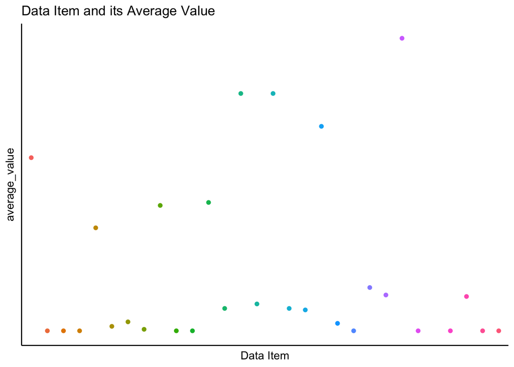

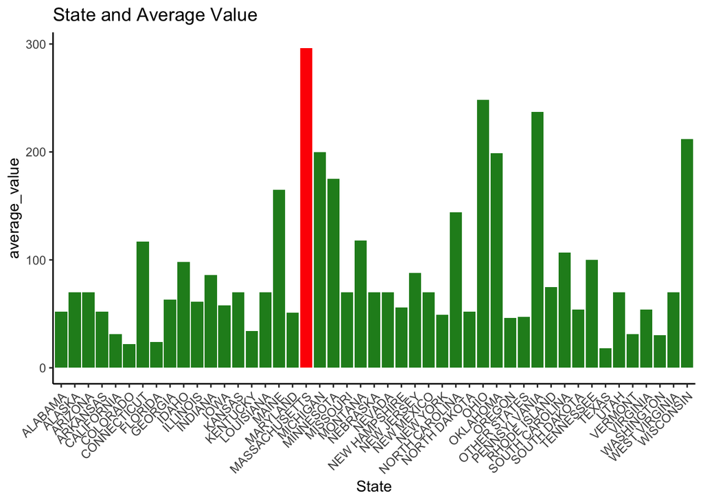

## Initial questions

- Initial questions about strawberries, the data, and about the work you are undertaking. Write these before you begin working.

I am Looking about the strawberry and it’s average value according to the state

## The data

Describe the source and original condition of the data: organization, problems with the data that needed to be addressed and so on. Cite data sources.

The data is come from the strwb_survey_mkt, to look at the question I am interested in, I need to know the average value that is classify by the state. Since there is lots of (D) in the value, and it will occurs error if they are not number, so I turn them into 0 and calculate out the mean value by its state.

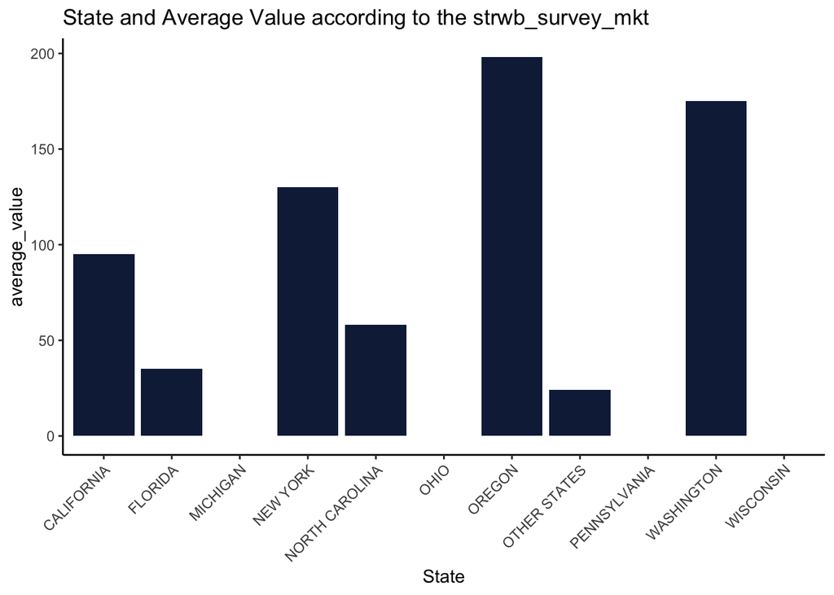

From the graph, we can see that OREGON has the highest value. I do some research about OREGON, and find out that OREGON has a long mild spring and has fertile alluvial soil, that’s the reason why it has the highest strawberry value.